# ECON_562_FINAL_PROJ_MOD_AF

## Categorical Predictor analysis

```r
library(vcd)
#create a contingency table with Categorical variables
bank_cat1 <- table(bank$b_tgt, bank$cat_input1)
bank_cat2 <- table(bank$b_tgt, bank$cat_input2)



# perform a Chi-squared test
chisq_test_cat1 <- chisq.test(bank_cat1)
chisq_test_cat2 <- chisq.test(bank_cat2)


# print the results
cat("Chi-squared test for b_tgt and cat_input1:\n")
```

```
## Chi-squared test for b_tgt and cat_input1:
```

```r
print(chisq_test_cat1)
```

```
##
##  Pearson's Chi-squared test
##
## data:  bank_cat1
## X-squared = 20362, df = 2, p-value < 2.2e-16
```

```r
cat("Chi-squared test for b_tgt and cat_input2:\n")
```

```
## Chi-squared test for b_tgt and cat_input2:
```

```r
print(chisq_test_cat2)
```

```
##
##  Pearson's Chi-squared test
##
## data:  bank_cat2
## X-squared = 16146, df = 4, p-value < 2.2e-16
```

```r
n <- nrow(bank)
v2 <- chisq_test_cat1$statistic / (n *4)
v1 <- chisq_test_cat2$statistic / (n *4)
```

```r
cat("Cramer's V for cat_input1:", sqrt(v2), "\n")
```

```
## Cramer's V for cat_input1: 0.06929801
```

```r
cat("Cramer's V for cat_input2:", sqrt(v1), "\n")
```

```
## Cramer's V for cat_input2: 0.0617084
```

#### Cramer’s V for cat_input1 and cat_input2 show that they likely have negligible effects on the b_tgt response variable given our sample size.

```r
#perform ANOVA test for cnt_tgt
anova_test_cnt_tgt <- aov(cnt_tgt ~ cat_input1 + cat_input2, data = bank)

#perform ANOVA test for int_tgt
anova_test_int_tgt <- aov(int_tgt ~  cat_input1 + cat_input2, data = bank)

# print the results
cat("ANOVA test for cnt_tgt:\n")
```

```
## ANOVA test for cnt_tgt:
```

```r
print(summary(anova_test_cnt_tgt))
```

```
##                  Df Sum Sq Mean Sq F value Pr(>F)
## cat_input1        2  10212    5106   10719 <2e-16 ***
## cat_input2        4   3761     940    1974 <2e-16 ***
## Residuals   1060031 504973       0
## ---
## Signif. codes:  0 '***' 0.001 '**' 0.01 '*' 0.05 '.' 0.1 ' ' 1
```

```r
cat("ANOVA test for int_tgt:\n")
```

```
## ANOVA test for int_tgt:
```

```r
print(summary(anova_test_int_tgt))
```

```
##                  Df    Sum Sq   Mean Sq F value Pr(>F)
## cat_input1        2 3.274e+11 1.637e+11    4832 <2e-16 ***
## cat_input2        4 3.851e+11 9.629e+10    2842 <2e-16 ***
## Residuals   1060031 3.591e+13 3.388e+07
## ---
## Signif. codes:  0 '***' 0.001 '**' 0.01 '*' 0.05 '.' 0.1 ' ' 1
```

#### Cat input 1 is only explaining 1.97% of the overall variance in cnt_tgt, and Cat Input 2 is only explaining .72% of the variance in cnt_tgt. Cat INput 1 is only explaining .89% of overall variance of int_tgt, and Cat Input 2 is explaining 1.05% of the overall variance in int_tgt. This is not enough variation in the data for me to include these variables in the candidate models for cnt_tgt or int_tgt.

```r
# Calculate effect sizes (eta-squared)
eta_cnt_input1 <- 10212 / (10212 + 3761 + 504973)
eta_cnt_input2 <- 3761 / (10212 + 3761 + 504973)

# Post-hoc analysis (Tukey HSD)
library(multcomp)
Tukey_cnt <- glht(aov(cnt_tgt ~ cat_input1 + cat_input2, data=bank),
                linfct = mcp(cat_input1 = "Tukey"))
summary(Tukey_cnt)
```

```
##
##   Simultaneous Tests for General Linear Hypotheses
##
## Multiple Comparisons of Means: Tukey Contrasts
##
##
## Fit: aov(formula = cnt_tgt ~ cat_input1 + cat_input2, data = bank)
##
## Linear Hypotheses:
##             Estimate Std. Error t value Pr(>|t|)
## Y - X == 0 -0.062475   0.002595  -24.07   <2e-16 ***
## Z - X == 0 -0.283639   0.001932 -146.81   <2e-16 ***
## Z - Y == 0 -0.221164   0.003054  -72.42   <2e-16 ***
## ---
## Signif. codes:  0 '***' 0.001 '**' 0.01 '*' 0.05 '.' 0.1 ' ' 1
## (Adjusted p values reported -- single-step method)
```

```r
#perform ANOVA test for cnt_tgt
anova_test_cnt_tgt <- aov(cnt_tgt ~ rfm1 + rfm2 + rfm8 + demog_age, data = bank)

#perform ANOVA test for int_tgt
anova_test_int_tgt <- aov(int_tgt ~  rfm1 + rfm2 + rfm8 + demog_age ,  data = bank)

# print the results
cat("ANOVA test for cnt_tgt:\n")
```

```
## ANOVA test for cnt_tgt:
```

```r
print(summary(anova_test_cnt_tgt))
```

```
##                  Df Sum Sq Mean Sq F value Pr(>F)
## rfm1              1   9065    9065 20729.7 <2e-16 ***
## rfm2              1  15766   15766 36050.8 <2e-16 ***
## rfm8              1  30465   30465 69663.6 <2e-16 ***
## demog_age         1     78      78   178.5 <2e-16 ***
## Residuals   1060033 463572       0
## ---
## Signif. codes:  0 '***' 0.001 '**' 0.01 '*' 0.05 '.' 0.1 ' ' 1
```

```r
cat("ANOVA test for int_tgt:\n")
```

```
## ANOVA test for int_tgt:
```

```r
print(summary(anova_test_int_tgt))
```

```
##                  Df    Sum Sq   Mean Sq F value   Pr(>F)
## rfm1              1 3.909e+10 3.909e+10  1161.7  < 2e-16 ***
## rfm2              1 2.243e+11 2.243e+11  6663.7  < 2e-16 ***
## rfm8              1 6.887e+11 6.887e+11 20465.7  < 2e-16 ***
## demog_age         1 5.586e+08 5.586e+08    16.6 4.62e-05 ***
## Residuals   1060033 3.567e+13 3.365e+07
## ---
## Signif. codes:  0 '***' 0.001 '**' 0.01 '*' 0.05 '.' 0.1 ' ' 1
```

# Outliers

```r
library(dplyr)
#create a new data frame with only the numeric variables from the data frame
numeric_vars <- bank %>% select(where(is.numeric))


#filter the numeric_vars dataframe to exclude missing values
numeric_vars <- numeric_vars %>% filter(complete.cases(.))

#compute the IQR for the numeric variables
IQR_values <- sapply(numeric_vars, IQR)


#Create a 3 column table data  showing the 25, 50, 75 percentiles for each numeric variable
# Create a data frame with the 25th, 50th, and 75th percentiles
percentiles <- data.frame(
  Variable = names(numeric_vars),
  Q25 = sapply(numeric_vars, quantile, probs = 0.25),
  Q50 = sapply(numeric_vars, quantile, probs = 0.50),
  Q75 = sapply(numeric_vars, quantile, probs = 0.75)
)

# Create the datatable and round the values to 2 decimal places
library(DT)
datatable(percentiles, options = list(pageLength = 10), rownames = FALSE) %>%
  formatRound(columns = 2:4, digits = 2) %>%
  formatStyle(columns = 1, fontWeight = 'bold') %>%
  formatStyle(columns = 2:4, backgroundColor = 'white') %>%
  formatStyle(columns = 1, backgroundColor = 'lightgreen') %>%
  formatStyle(columns = 1, textAlign = 'center') %>%
  formatStyle(columns = 2:4, textAlign = 'center')
```

| Variable | Q25 | Q50 | Q75 |
| --- | --- | --- | --- |
| int_tgt | 0 | 0 | 0 |
| cnt_tgt | 0 | 0 | 0 |
| demog_age | 50 | 58 | 69 |
| demog_homeval | 51107 | 73880 | 122214 |
| demog_inc | 26084 | 43174 | 56896 |
| demog_pr | 25 | 31 | 37 |
| rfm1 | 10 | 15 | 20 |
| rfm2 | 8.4 | 11.67 | 15.5 |
| rfm3 | 10 | 14.88468102388317 | 20 |
| rfm4 | 10 | 15 | 20 |

[output cut: 9 more lines]

```r
library(tibble)

#find the count of observations that are greater than 2 times the Q75 IQR label them as "high outliers"
high_outliers <- sapply(numeric_vars, function(x) sum(x > (quantile(x, 0.75) + 2 * IQR(x))))

# Convert to a data frame and rename the columns
high_outliers <- as.data.frame(high_outliers)


#find the count of observations that are less than 2 times the Q25 IQR label them as "low outliers"
low_outliers <- sapply(numeric_vars, function(x) sum(x < (quantile(x, 0.25) - 2 * IQR(x))))

# Convert to a data frame and rename the columns
low_outliers <- as.data.frame(low_outliers)
# Combine the two data frames
outliers <- cbind(high_outliers, low_outliers)
# Rename the columns
colnames(outliers) <- c("High Outliers", "Low Outliers")
# Create a data frame with the variable names
outliers <- tibble::rownames_to_column(outliers, "Variable")
# Create the datatable
library(DT)
#exclude the variables with no outliers
outliers <- outliers %>% filter(`High Outliers` > 0 | `Low Outliers` > 0)
# Create the datatable
datatable(outliers, options = list(pageLength = 10)) %>%
  formatRound(columns = 2:3, digits = 2) %>%
  formatStyle(columns = 1, fontWeight = 'bold') %>%
  formatStyle(columns = 2:3, backgroundColor = 'white') %>%
  formatStyle(columns = 1, backgroundColor = 'lightgreen') %>%
  formatStyle(columns = 1, textAlign = 'center') %>%
  formatStyle(columns = 2:3, textAlign = 'center')
```

|  | Variable | High Outliers | Low Outliers |
| --- | --- | --- | --- |
| 1 | int_tgt | 207593 | 0 |
| 2 | cnt_tgt | 211509 | 0 |
| 3 | demog_age | 0 | 5329 |
| 4 | demog_homeval | 73306 | 0 |
| 5 | demog_inc | 8470 | 0 |
| 6 | demog_pr | 7858 | 31245 |
| 7 | rfm1 | 22992 | 0 |
| 8 | rfm2 | 29359 | 0 |
| 9 | rfm3 | 24256 | 0 |
| 10 | rfm4 | 30067 | 0 |

[output cut: 8 more lines]

```r
#export the outliers data frame to a csv
write.csv(outliers, "outliers.csv", row.names = FALSE)
```

```r
#view the complete observation for when int_tgt == 500000
bank[bank$int_tgt > 100000, ]
```

```
## # A tibble: 55 × 26
##    b_tgt int_tgt cnt_tgt cat_input1 cat_input2 demog_age demog_ho demog_homeval
##    <fct>   <dbl>   <dbl> <fct>      <fct>          <dbl> <fct>            <dbl>
##  1 yes    200000       1 X          A               57   yes             169771
##  2 yes    200000       1 Y          B               76   no              100111
##  3 yes    200000       1 X          A               71   yes             217081
##  4 yes    500000       1 X          E               49.0 no               64972
##  5 yes    112000       1 X          C               42   yes                  0
##  6 yes    200000       1 X          A               58   yes             169803
##  7 yes    200000       1 X          A               76   no              100090
##  8 yes    200000       1 X          A               72   yes             217106
##  9 yes    500000       1 X          E               48.8 no               64995
## 10 yes    112000       1 X          C               42   yes                  0
## # ℹ 45 more rows
## # ℹ 18 more variables: demog_inc <dbl>, demog_pr <dbl>, rfm1 <dbl>, rfm2 <dbl>,
## #   rfm3 <dbl>, rfm4 <dbl>, rfm5 <dbl>, rfm6 <dbl>, rfm7 <dbl>, rfm8 <dbl>,
## #   rfm9 <dbl>, rfm10 <dbl>, rfm11 <dbl>, rfm12 <dbl>, demog_genf <fct>,
## #   demog_genm <fct>, account <dbl>, dataset <chr>
```

#### there are 11 observations where int_tgt = 500K. This data point seems off when we look at the values of the other predictors when int_tgt is $500k. There is little to no variation in the income, demographics,and new sales data that that makes up these observations. When we look at observations where int_tgt > $100k , we see significantly more variation in the predictor set. It is only 11 obs, but they’re erroneous. I am going to reclassify them based on income. Int_tgt == 500K will now take the average value of Int_tgt when deomog_inc is between $60k - $70K The other high value Int_tgt observations over $100k are somewhat more realistic, as there is variation in the homevalue, income, and age demographic predictors that accompany these observations. There are a sparse number of these observations (44 in total), but they could be true customers of these banks. They might have bought a home loan or education loans.

```r
#reclassify the int_tgt == 500K observations based on income
bank$int_tgt[bank$int_tgt == 500000] <- mean(bank$int_tgt[bank$demog_inc > 60000 & bank$demog_inc < 70000], na.rm = TRUE)
# Check the summary of the imputed variable
cat("Summary of imputed int_tgt:\n")
```

```
## Summary of imputed int_tgt:
```

```r
summary(bank$int_tgt)
```

```
##    Min. 1st Qu.  Median    Mean 3rd Qu.    Max.
##       0       0       0    2237       0  200000
```

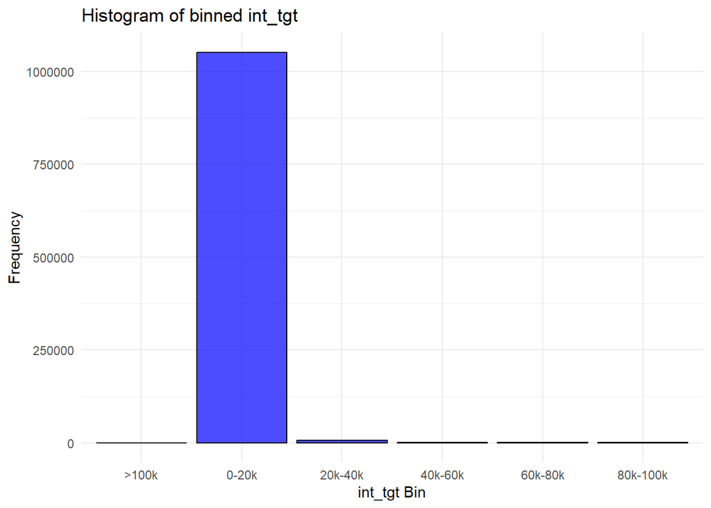

```r
#bin the observations of int_tgt into 6 bins - up to $200k
library(dplyr)
bank <- bank %>%
  mutate(int_tgt_bin = case_when(
    int_tgt <= 20000 ~ "0-20k",
    int_tgt > 20000 & int_tgt <= 40000 ~ "20k-40k",
    int_tgt > 40000 & int_tgt <= 60000 ~ "40k-60k",
    int_tgt > 60000 & int_tgt <= 80000 ~ "60k-80k",
    int_tgt > 80000 & int_tgt <= 100000 ~ "80k-100k",
    TRUE ~ ">100k"
  ))
# Create a histogram of the binned int_tgt variable
ggplot(bank, aes(x = int_tgt_bin)) +
  geom_bar(fill = "blue", color = "black", alpha = 0.7) +
  labs(title = "Histogram of binned int_tgt", x = "int_tgt Bin", y = "Frequency") +
  theme_minimal()
```

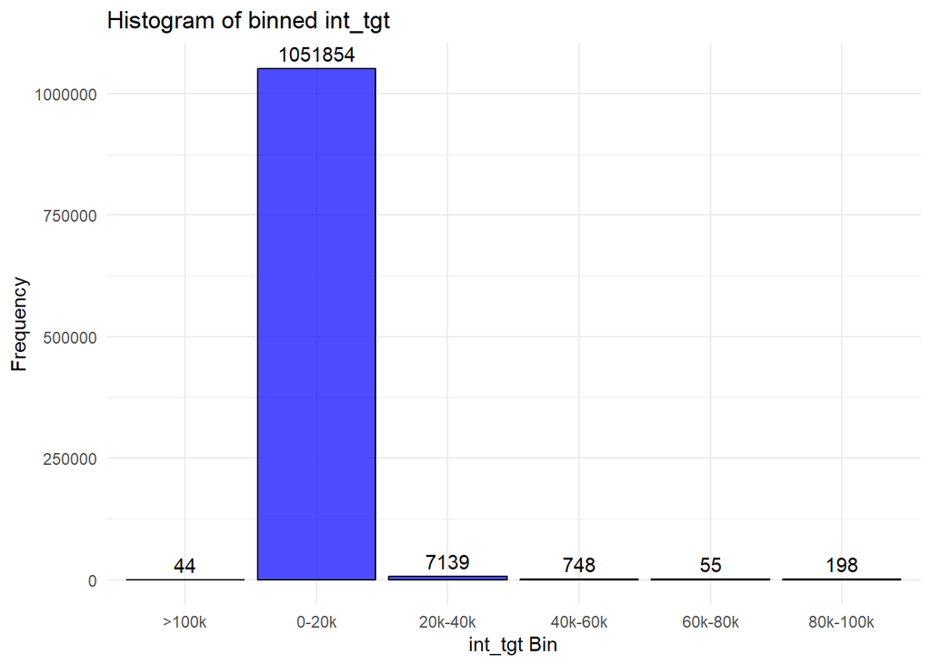

```r
#add the exact count number for each bin to the histogram
ggplot(bank, aes(x = int_tgt_bin)) +
  geom_bar(fill = "blue", color = "black", alpha = 0.7) +
  geom_text(stat = 'count', aes(label = ..count..), vjust = -0.5) +
  labs(title = "Histogram of binned int_tgt", x = "int_tgt Bin", y = "Frequency") +
  theme_minimal()
```

```r
summary(bank$cnt_tgt)
```

```
##    Min. 1st Qu.  Median    Mean 3rd Qu.    Max.
##  0.0000  0.0000  0.0000  0.3118  0.0000  6.0000
```

```r
#calculate 2x over the 3Q for cnt_tgt
cnt_tgt_3Q <- quantile(bank$cnt_tgt, 0.75) + 2 * IQR(bank$cnt_tgt)

#count the number of cnt_tgt observations that are greater than 2x the 3Q
count_high_cnt_tgt <- sum(bank$cnt_tgt > cnt_tgt_3Q)

print(paste("Number of cnt_tgt observations greater than 2x the 3Q:", count_high_cnt_tgt))
```

```
## [1] "Number of cnt_tgt observations greater than 2x the 3Q: 211509"
```

```r
print(paste("cnt_tgt 3Q:", cnt_tgt_3Q))
```

```
## [1] "cnt_tgt 3Q: 0"
```

```r
#show the observations wher cnt_tgt = 6
bank[bank$cnt_tgt == 6, ]
```

```
## # A tibble: 11 × 27
##    b_tgt int_tgt cnt_tgt cat_input1 cat_input2 demog_age demog_ho demog_homeval
##    <fct>   <dbl>   <dbl> <fct>      <fct>          <dbl> <fct>            <dbl>
##  1 yes     16000       6 X          E               56.7 yes             127994
##  2 yes     16000       6 X          E               56.7 yes             127991
##  3 yes     16000       6 X          E               56.7 yes             127989
##  4 yes     16000       6 X          E               56.5 yes             127988
##  5 yes     16000       6 X          E               56.7 yes             127989
##  6 yes     16000       6 X          E               56.7 yes             127991
##  7 yes     16000       6 X          E               56.7 yes             127995
##  8 yes     16000       6 X          E               56.7 yes             128000
##  9 yes     16000       6 X          E               56.7 yes             128006
## 10 yes     16000       6 X          E               56.7 yes             127995
## 11 yes     16000       6 X          E               56.7 yes             128039
## # ℹ 19 more variables: demog_inc <dbl>, demog_pr <dbl>, rfm1 <dbl>, rfm2 <dbl>,
## #   rfm3 <dbl>, rfm4 <dbl>, rfm5 <dbl>, rfm6 <dbl>, rfm7 <dbl>, rfm8 <dbl>,
## #   rfm9 <dbl>, rfm10 <dbl>, rfm11 <dbl>, rfm12 <dbl>, demog_genf <fct>,
## #   demog_genm <fct>, account <dbl>, dataset <chr>, int_tgt_bin <chr>
```

```r
#reclassify the observations when cnt_tgt == 6 based on income
bank$cnt_tgt[bank$cnt_tgt == 6] <- mean(bank$cnt_tgt[bank$demog_inc > 30000 & bank$demog_inc < 35000], na.rm = TRUE)

#round the imputed values to the nearest whole number
bank$cnt_tgt[bank$cnt_tgt == 6] <- round(bank$cnt_tgt[bank$cnt_tgt == 6])

#show the imputed data points
```